# Praca domowa 2

Imię Nazwisko

## Dane

Dane wykorzystane w Pracy domowej 2 opisują wycenę nieruchmości. Każda obserwacja jest pewną nieruchmością, która posiada informacje takie jak powierzchnia, liczba pokoi, liczba łazienek i wiele więcj. Opis wszystkich kolumn w pliku `README.md`.

## Zadanie 1

Jak wygląda rozkład ceny nieruchomości w poszczególnych kodach pocztowych na przestrzeni lat? Rozważamy kody pocztowe, które mają więcej niż 280 posiadłości.

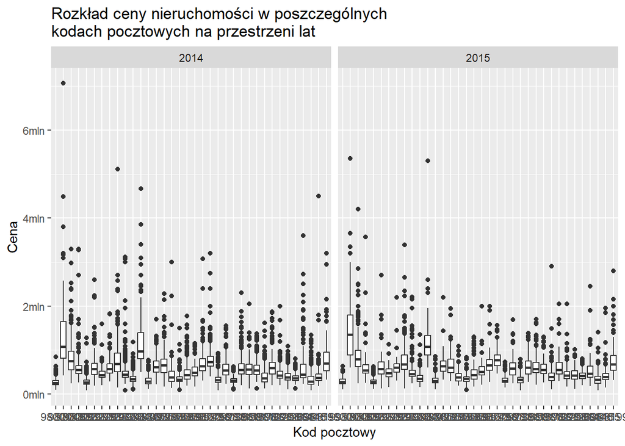

```r
app_zipcodes <- df %>%
  mutate(year = substr(date,1,4)) %>%
  group_by(zipcode) %>%
  summarise(amount_of_properties = n()) %>%
  filter(amount_of_properties > 280)



df %>%
  mutate(year = substr(date,1,4)) %>%
  filter(zipcode %in% app_zipcodes$zipcode) %>%
  ggplot(aes(x=as.factor(zipcode), y = price)) + geom_boxplot() + facet_grid(~year) +
  labs(x = "Kod pocztowy", y = "Cena", title = "Rozkład ceny nieruchomości w poszczególnych
kodach pocztowych na przestrzeni lat") +
  scale_y_continuous(labels = scales::label_number(scale = 1e-6, suffix = "mln"))
```

**Komentarz:** Rozkład ceny nieruchomości na przestrzeni lat - 2014 i 2015 nie różni się od siebie w większym stopniu. Wykresy z obu lat są bardzo do siebie zbliżone.

## Zadanie 2

Czy jest różnica w rozkładzie ceny nierchomości od powierzchni mieszkalnej uwzględniając podział na nieruchomości z piwnicą i bez?

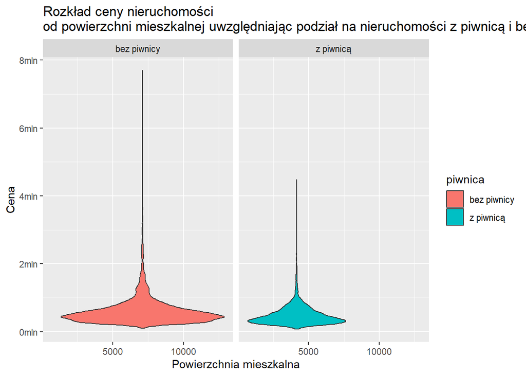

```r
df %>%
  mutate(piwnica = ifelse(sqft_basement==0,'z piwnicą','bez piwnicy')) %>%
  ggplot(aes(x = sqft_living,y = price, fill = piwnica)) + geom_violin() +
  facet_grid(~piwnica) +scale_y_continuous(labels = scales::label_number(scale = 1e-6, suffix = "mln"))+
  labs(x = "Powierzchnia mieszkalna", y = "Cena", title = "Rozkład ceny nieruchomości
od powierzchni mieszkalnej uwzględniając podział na nieruchomości z piwnicą i bez")
```

## Zadanie 3

Jaka jest zależność pomiędzy jakością wykończenia nieruchomości a liczbą pięter?

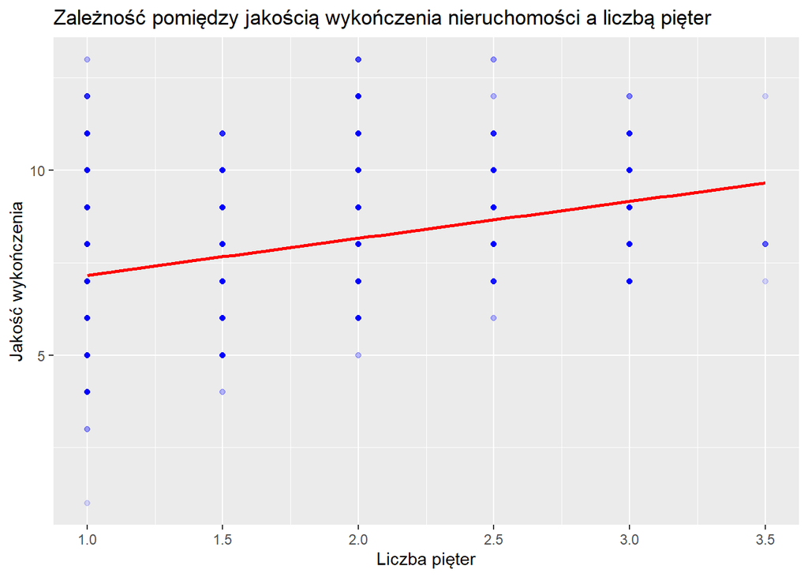

```r
ggplot(df, aes(x = floors, y = grade)) +
  geom_point(color = 'blue',alpha=0.15)+geom_smooth(method = "lm", color = "red", se = FALSE)+
  labs(title = "Zależność pomiędzy jakością wykończenia nieruchomości a liczbą pięter",
       y = "Jakość wykończenia", x = "Liczba pięter")
```

**Komentarz:** Z wykresu wnioskuję, że im większa liczba pięter w nieruchomości, tym większa jakość wykończenia.

## Zadanie 4

Jaka jest zależność między powierzchnią mieszkalną nieruchomości a powierzchnią gruntu w podziale na liczbę sypialni?

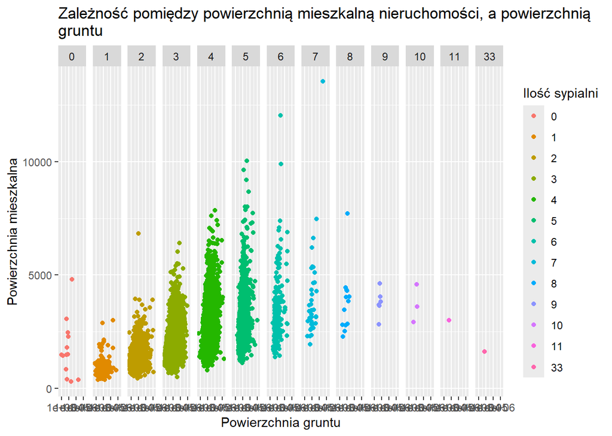

```r
ggplot(df, aes(x = sqft_lot, y = sqft_living, color = as.factor(bedrooms))) + geom_point() +
  facet_grid(~bedrooms) + scale_x_log10()+
  labs(title = "Zależność pomiędzy powierzchnią mieszkalną nieruchomości, a powierzchnią
gruntu", y = "Powierzchnia mieszkalna", x = "Powierzchnia gruntu", color = "Ilość sypialni")
```

**Komentarz:** Widać, że nie ma zależności pomiędzy powierzchnią mieszkalną nieruchomości a powierzchnią gruntu w podziale na liczbę sypialni.

## Zadanie 5

Rozważmy tylko nieruchomości, które miały remont. W której dekadzie było najwięcej przeprowadzonych remontów? Czy w poszczególnych dekadach jest porównywalny procent nieruchmości dla każdej wartości miary jakości i wykończenia nieruchomości?

```r
renovations_per_decade <- df %>%
  filter(yr_renovated != 0) %>%
  mutate(decade = floor(as.numeric(yr_renovated)/10)*10) %>%
  group_by(decade) %>%
  summarise(amount_of_renovations = n())

plot1 <- ggplot(renovations_per_decade,aes(x = as.factor(decade), y = amount_of_renovations)) +
  geom_bar(stat = "identity", fill = "steelblue")+
  labs(x = "Dekady", y = "Liczba remontów", title = "Liczba przeprowadzonych remontów w
poszczególnych dekadach")


percent_per_grade <- df %>%
  filter(yr_renovated != 0) %>%
  mutate(decade = floor(as.numeric(yr_renovated)/10)*10) %>%
  group_by(decade,grade) %>%
  summarise(amount_of_renovations_per_grade = n()) %>%
  left_join(renovations_per_decade, by = 'decade') %>%
  mutate(percent = amount_of_renovations_per_grade/amount_of_renovations)

plot2 <- ggplot(percent_per_grade, aes(x = as.factor(decade), y = percent))+
  geom_bar(stat = "identity", fill = "steelblue") + facet_wrap(~grade) +
  labs(x = "Dekady", y = "Procent nieruchomości", title = "Procent nieruchmości dla każdej wartości
miary jakości i wykończenia nieruchomości w poszczególnych dekadach")
```

[output not shown]

## Zadanie 6

Jak prezentuje się wartość minimalna, średnia i maksymalna ceny nieruchmości w podziele na rok budowy nieruchomości.

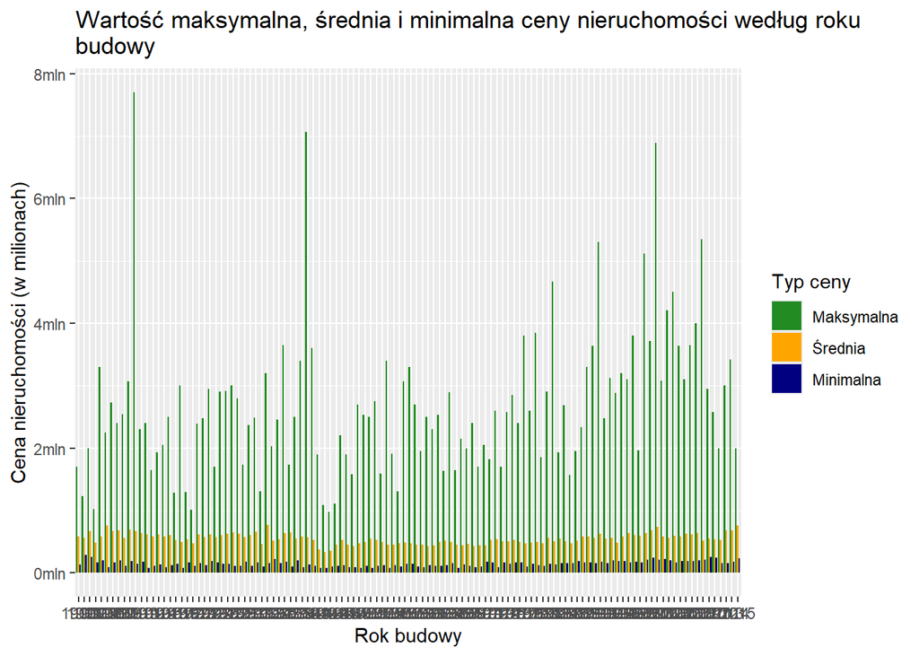

```r
summary_df <- df %>%
  group_by(yr_built) %>%
  summarise(
    min_price = min(price, na.rm = TRUE),
    mean_price = mean(price, na.rm = TRUE),
    max_price = max(price, na.rm = TRUE),
    .groups = 'drop'
  ) %>%
  tidyr::pivot_longer(cols = c(min_price, mean_price, max_price),
               names_to = "price_type",
               values_to = "price_value")



ggplot(summary_df, aes(x = as.factor(yr_built), y = price_value, fill = price_type)) +
  geom_bar(stat = "identity", position = "dodge") +
  scale_y_continuous(labels = scales::label_number(scale = 1e-6, suffix = "mln")) +
  labs(x = "Rok budowy", y = "Cena nieruchomości (w milionach)", title = "Wartość maksymalna, średnia i minimalna ceny nieruchomości według roku
budowy")+
  scale_fill_manual(
    name = "Typ ceny",
    labels = c("Maksymalna", "Średnia", "Minimalna"),
    values = c("forestgreen", "orange", "navy"))
```

**Komentarz:** Cena średnia i minimalna nieruchomości w podziele na rok budowy jest do siebie zbliżona, natomiast są drastyczne różnice pomiędzy wartościami maksymalnymi.